# R Notebook

# Question 2

## Necessary library

Necessary library was imported into R.

```r
library(tidyverse)
library(readxl)
library(caret)
```

## Importing data

The data will first be imported into R, and observe the summary statistics of the data.

```r
data <- read_excel("Fish Weight-3Only-Random.xlsx")
attach(data)
summary(data)
```

```
   Species              Weight           Height           Width
 Length:111         Min.   :   5.9   Min.   : 2.112   Min.   :1.408
 Class :character   1st Qu.: 137.5   1st Qu.: 6.192   1st Qu.:3.624
 Mode  :character   Median : 300.0   Median : 8.877   Median :4.566
                    Mean   : 416.1   Mean   : 9.960   Mean   :4.765
                    3rd Qu.: 687.5   3rd Qu.:13.681   3rd Qu.:6.011
                    Max.   :1100.0   Max.   :18.957   Max.   :8.142
```

```r
str(data)
```

```
tibble [111 × 4] (S3: tbl_df/tbl/data.frame)
 $ Species: chr [1:111] "Bream" "Bream" "Bream" "Bream" ...
 $ Weight : num [1:111] 430 700 975 500 475 600 575 700 610 620 ...
 $ Height : num [1:111] 12.4 14.9 18.6 14.2 14.3 ...
 $ Width  : num [1:111] 5.13 5.29 6.75 4.96 5.1 ...
```

```r
head(data)
```

| Species | Weight | Height | Width |
| --- | --- | --- | --- |
| Bream | 430 | 12.4440 | 5.1340 |
| Bream | 700 | 14.8604 | 5.2854 |
| Bream | 975 | 18.6354 | 6.7473 |
| Bream | 500 | 14.2266 | 4.9594 |
| Bream | 475 | 14.2628 | 5.1042 |
| Bream | 600 | 14.9544 | 5.1708 |

## One-hot coding

Doing one-hot coding for Bream, Roach, and Perch.

```r
data <- data %>%
  mutate("Bream-D" = ifelse(Species == "Bream",1,0),
         "Roach-D" = ifelse(Species == "Roach",1,0),)
head(data)
```

| Species | Weight | Height | Width | Bream-D | Roach-D |
| --- | --- | --- | --- | --- | --- |
| Bream | 430 | 12.4440 | 5.1340 | 1 | 0 |
| Bream | 700 | 14.8604 | 5.2854 | 1 | 0 |
| Bream | 975 | 18.6354 | 6.7473 | 1 | 0 |
| Bream | 500 | 14.2266 | 4.9594 | 1 | 0 |
| Bream | 475 | 14.2628 | 5.1042 | 1 | 0 |
| Bream | 600 | 14.9544 | 5.1708 | 1 | 0 |

```r
tail(data)
```

| Species | Weight | Height | Width | Bream-D | Roach-D |
| --- | --- | --- | --- | --- | --- |
| Roach | 40 | 4.1472 | 2.2680 | 0 | 1 |
| Roach | 140 | 6.5500 | 3.3250 | 0 | 1 |
| Roach | 390 | 9.4850 | 5.3550 | 0 | 1 |
| Roach | 120 | 6.2160 | 3.5742 | 0 | 1 |
| Roach | 169 | 7.5344 | 3.8352 | 0 | 1 |
| Roach | 150 | 5.8045 | 3.7544 | 0 | 1 |

## Plotting data

We can plot out the data to observe the pattern behind.

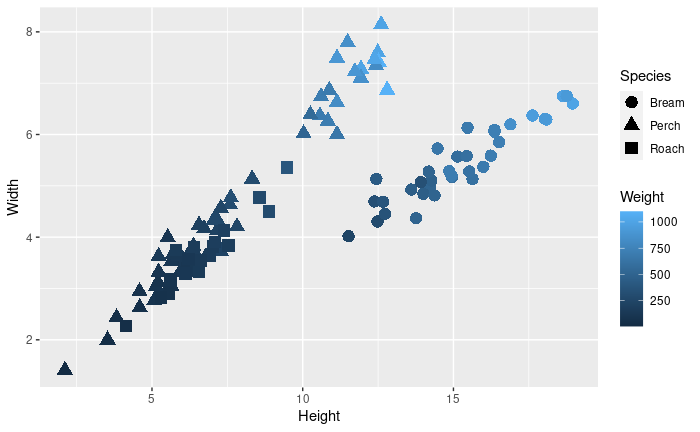

```r
ggplot(data) +
  geom_point(aes(Height,Width, color = Weight, shape = Species), size = 4)
```

From the graph, we can see the obvious trend, which is fish with larger `Width` and `Height` has heavier weight. Besides, `Bream` generally clustered separately from the other 2 species at large `Height` value; while the other 2 are somewhat mixed. `Roach` species generally forms a cluster at lesser `Height` and `Width` while `Perch` has greater variation in their `Width` and `Height`. `Roach` tends to have the lowest mean `Weight` among the species.

## Correlation between predictor

Now we will compute the correlation matrix between the numeric predictor for `Weight`

```r
cor(select(data,Weight, Height, Width))
```

```
          Weight    Height     Width
Weight 1.0000000 0.8420711 0.9489142
Height 0.8420711 1.0000000 0.7624014
Width  0.9489142 0.7624014 1.0000000
```

We can see that both numeric predictor `Height` and `Weight` are highly positive correlated. It suggest that normally fish with great `Height` will have great `Width`. We try to combine both `Height` and `Width` into an interaction term $HW = Height\cdot Width$ and see how it correlates to `Weight`.

```r
select(data, Weight, Height, Width) %>%
  mutate(HW = Height*Width) %>%
  select(Weight, HW) %>%
  cor()
```

```
          Weight        HW
Weight 1.0000000 0.9532993
HW     0.9532993 1.0000000
```

We can see that the new interaction term is more positively correlated to `Weight` than `Width` and `Height` alone. Hence, we will try to fit this interaction into the second model to see if it yields higher $R^2_{adj}$.

## Spliting data 80-20

The data is split into 80-20 for training-test sets for each `Species`.

```r
BreamTraining <- filter(data, Species == "Bream") %>%
  head(dim(.)[1]*0.8)
BreamTest <- filter(data, Species == "Bream") %>%
  tail(dim(.)[1]*0.2)

tableBream <- c(RawSize = dim(filter(data,Species == "Bream"))[1],
                TrainingSize = dim(BreamTraining)[1],
                TestSize = dim(BreamTest)[1])

RoachTraining <- filter(data, Species == "Roach") %>%
  head(dim(.)[1]*0.8)
RoachTest <- filter(data, Species == "Roach") %>%
  tail(dim(.)[1]*0.2)

tableRoach <- c(RawSize = dim(filter(data,Species == "Roach"))[1],
                TrainingSize = dim(RoachTraining)[1],
                TestSize = dim(RoachTest)[1])

PerchTraining <- filter(data, Species == "Perch") %>%
  head(dim(.)[1]*0.8)
PerchTest <- filter(data, Species == "Perch") %>%
  tail(dim(.)[1]*0.2)

tablePerch <- c(RawSize = dim(filter(data,Species == "Perch"))[1],
                TrainingSize = dim(PerchTraining)[1],
                TestSize = dim(PerchTest)[1])

splitSize <- rbind(tableBream, tableRoach, tablePerch)
row.names(splitSize) <- c("Bream","Roach","Perch")
splitSize
```

```
      RawSize TrainingSize TestSize
Bream      35           28        7
Roach      20           16        4
Perch      56           44       12
```

```r
TrainingSet <- rbind(BreamTraining, RoachTraining, PerchTraining)
TestSet <- rbind(BreamTest, RoachTest, PerchTest)
```

## Linear regression

The training data will then trained to fit into 2 linear model as follow:

$\hat{Weight_1} = \hat{\beta_0} + \hat{\beta_1}\cdot Height + \hat{\beta_2}\cdot Width + \hat{\beta_3}\cdot \mbox{Bream-D} + \hat{\beta_4}\cdot\mbox{Roach-D}$

$\hat{Weight_2} = \hat{\beta_0} + \hat{\beta_1}\cdot Height + \hat{\beta_2}\cdot Width + \hat{\beta_3}\cdot Height\cdot Width + \hat{\beta_4}\cdot \mbox{Bream-D} + \hat{\beta_5}\cdot\mbox{Roach-D}$

```r
model1 <- train(Weight ~ Height + Width + `Bream-D` + `Roach-D`,
                data = TrainingSet, method = "lm")

summary(model1)
```

```
Call:
lm(formula = .outcome ~ ., data = dat)

Residuals:
    Min      1Q  Median      3Q     Max
-162.18  -39.44  -13.18   25.90  274.05

Coefficients:
                Estimate Std. Error t value Pr(>|t|)
(Intercept)      -515.82      29.35 -17.573  < 2e-16 ***
Height             71.92      10.96   6.562 4.29e-09 ***
Width              68.02      19.33   3.519 0.000705 ***
`\\`Bream-D\\``  -327.68      68.62  -4.775 7.62e-06 ***
`\\`Roach-D\\``   -50.42      22.90  -2.202 0.030445 *
---
Signif. codes:  0 ‘***’ 0.001 ‘**’ 0.01 ‘*’ 0.05 ‘.’ 0.1 ‘ ’ 1

Residual standard error: 69.83 on 83 degrees of freedom
Multiple R-squared:  0.948, Adjusted R-squared:  0.9455
F-statistic: 378.3 on 4 and 83 DF,  p-value: < 2.2e-16
```

```r
model2 <- train(Weight ~ Height * Width + `Bream-D` + `Roach-D`,
                data = TrainingSet, method = "lm")

summary(model2)
```

```
Call:
lm(formula = .outcome ~ ., data = dat)

Residuals:
     Min       1Q   Median       3Q      Max
-146.431  -29.408    0.202   19.443  181.125

Coefficients:
                Estimate Std. Error t value Pr(>|t|)
(Intercept)     -133.068     61.289  -2.171  0.03281 *
Height             1.459     13.651   0.107  0.91517
Width             19.973     17.114   1.167  0.24658
`\\`Bream-D\\`` -175.619     59.683  -2.943  0.00423 **
`\\`Roach-D\\``  -29.038     18.719  -1.551  0.12469
`Height:Width`     9.543      1.410   6.769 1.79e-09 ***
---
Signif. codes:  0 ‘***’ 0.001 ‘**’ 0.01 ‘*’ 0.05 ‘.’ 0.1 ‘ ’ 1

Residual standard error: 56.27 on 82 degrees of freedom
Multiple R-squared:  0.9666,    Adjusted R-squared:  0.9646
F-statistic: 475.2 on 5 and 82 DF,  p-value: < 2.2e-16
```

```r
comparison <- rbind(model1$results, model2$results)
rownames(comparison) <- c("training1", "training2")
comparison
```

|  | intercept | RMSE | Rsquared | MAE | RMSESD | RsquaredSD | MAESD |
| --- | --- | --- | --- | --- | --- | --- | --- |
| training1 | TRUE | 74.99499 | 0.9438336 | 52.46929 | 11.197090 | 0.01445597 | 6.05898 |
| training2 | TRUE | 61.28357 | 0.9613389 | 43.25708 | 6.327358 | 0.00827177 | 5.23193 |

```r
anova(model1$finalModel, model2$finalModel)
```

```
Analysis of Variance Table

Model 1: .outcome ~ Height + Width + `\`Bream-D\`` + `\`Roach-D\``
Model 2: .outcome ~ Height + Width + `\`Bream-D\`` + `\`Roach-D\`` + `Height:Width`
  Res.Df    RSS Df Sum of Sq      F   Pr(>F)
1     83 404681
2     82 259605  1    145076 45.824 1.79e-09 ***
---
Signif. codes:  0 ‘***’ 0.001 ‘**’ 0.01 ‘*’ 0.05 ‘.’ 0.1 ‘ ’ 1
```

We can see that the ANOVA test $p=1.79\times 10^{-9}$, which rejects the null hypothesis that both model performs equally well. There is sufficient evidence that `model2` performs significantly different than `model1`.

## Test model

Now we can use both trained `model1` and `model2` on our `TestSet`.

```r
predict1 <- predict(model1, select(TestSet,-Species))
predict2 <- predict(model2, select(TestSet,-Species))
predict1
```

```
         1          2          3          4          5          6          7          8          9         10         11         12
 857.31649  646.36327  882.68244  747.49355  704.69298  517.59101  742.43387  480.17303  123.93509  236.50968  106.59574  318.55279
        13         14         15         16         17         18         19         20         21         22         23
 -75.37311  825.46515  882.20234  183.70219  871.96453  944.47959  819.24820  332.59608  151.84879 -126.09975  143.04824
```

Now we can create a function for metric reporting that report metrics such as $R^2$, $R^2_{Adj}$ and $RMSE$ as there is no built in metric reporting for prediction of data.

```r
metric <- function(raw, predict, nPredictor, dp = 5){
  n <- length(predict)
  SSE <- sum((raw - predict) ^ 2)
  SST <- sum((raw - (sum(raw)/n)) ^ 2)
  R2 <- 1 - SSE/SST
  R2adj <- 1 - (((1 - R2)*(n - 1))/(n - nPredictor - 1))
  RMSE <- sqrt(SSE/n)
  table <- data.frame(cbind(n, round(SSE,dp), round(SST,dp), round(R2,dp),
             round(R2adj,dp), round(RMSE,dp)))
  colnames(table) <- c("n","SSE","SST","R2","R2adj","RMSE")
  return(table)
}
```

Now, we can do the metric reporting.

```r
testMetric1 <- metric(select(TestSet,Weight), predict1, length(model1$finalModel$coefficients)-1)
testMetric2 <- metric(select(TestSet,Weight), predict2, length(model2$finalModel$coefficients)-1)

trainMetric1 <- predict(model1, select(TrainingSet, -Species)) %>%
  metric(select(TrainingSet,Weight), ., length(model1$finalModel$coefficients)-1)

trainMetric2 <- predict(model2, select(TrainingSet, -Species)) %>%
  metric(select(TrainingSet,Weight), ., length(model2$finalModel$coefficients)-1)

options(scipen = 999) # to turn of the scientific notation

allMetric <- rbind(trainMetric1, trainMetric2, testMetric1, testMetric2)
rownames(allMetric) <- c("train1","train2","test1","test2")
allMetric
```

|  | n | SSE | SST | R2 | R2adj | RMSE |
| --- | --- | --- | --- | --- | --- | --- |
| train1 | 88 | 404681.49 | 7782312 | 0.94800 | 0.94549 | 67.81337 |
| train2 | 88 | 259605.16 | 7782312 | 0.96664 | 0.96461 | 54.31444 |
| test1 | 23 | 161972.22 | 3036604 | 0.94666 | 0.93481 | 83.91824 |
| test2 | 23 | 94354.64 | 3036604 | 0.96893 | 0.95979 | 64.04979 |

## Not randomized data

If the data is sorted according to weight and is not randomized at the beginning (by Prof. in this case), the model trained will biased towards the group with smaller weight (80th percentile) if first 80% is taken as training set. As a result, the model trained might have a low Training $RMSE$ and high Training $R^2_{adj}$ but high Test $RMSE$ and low Test $R^2_{adj}$. The data selected in this case does not take into account the variation of data for fishes with larger weight and in fact, linear regression is good for interpolation but not good for extrapolation.